# Exploratory Data Analysis

B.G.H.Piyumika

9/4/2020

### **Loading Required Packages**

In order to do the Exploratory Data Analysis first of all it has to be loaded some packages. Some packages were required for further data wrangling part and some packages needed for obtain plots.

Following are some packaged that have been loaded. The rest of packages were loaded where necessary.

```r
library(tidyverse)
library(magrittr)
library(sf)
library(raster)
library(dplyr)
library(spData)
```

```r
library(tmap)
library(leaflet)
library(ggplot2)
library(rworldmap)
```

### **Loading the the cleaned data set**

Here it has been loaded the cleaned data set which was cleaned by last session Data Wrangling. The cleaned data set has assigned to a data frame called “MyDataSet”

```r
library(readxl)
MyDataSet<-read_excel("MyOutput1.xlsx")
```

```
* `` -> ...1
```

```r
#MyDataSet
```

```r
MyDataSet<-MyDataSet[!(is.na(MyDataSet$Job_title)),]
#MyDataSet
```

```r
MyDataSet<-MyDataSet%>%dplyr::na_if("Not_define")
MyDataSet<-MyDataSet%>%dplyr::na_if("Not_mentioned")
MyDataSet<-MyDataSet%>%dplyr::na_if("Not-mentioned")
MyDataSet<-MyDataSet%>%dplyr::na_if("not mentioned")
MyDataSet<-MyDataSet%>%dplyr::na_if("Competitive")
MyDataSet<-MyDataSet%>%dplyr::na_if("NA")
#MyDataSet
```

```r
MyDataSet<-MyDataSet%>%mutate(Job_title=tolower(Job_title))
#MyDataSet
```

```r
MyDataSet$Job_title<-gsub('&',"and",MyDataSet$Job_title)
MyDataSet<-distinct(MyDataSet,Job_title,Company,URL,.keep_all = TRUE)
#MyDataSet
```

### **World Map**

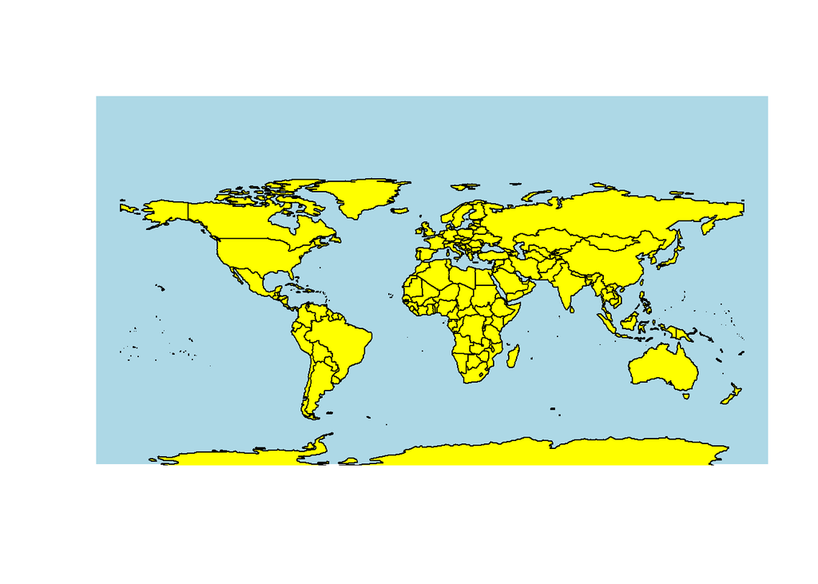

```r
worldmap<-getMap(resolution = "coarse")
plot(worldmap,xlim=c(-180,180),ylim=c(-50,100),asp=1,bg="lightblue",col="yellow")
```

### **Required Softwares**

There are 36 softwares in our data set. They were distributed in 36 columns. Those softwares have assigned into one column by using the followin code.

```r
sw1<-pivot_longer(MyDataSet,c(7:19,25,26,31:33,35,36,38:40,53,56:58,62,63,65,66,70:74),"RequiredSoftwares","Status")
sw2<-filter(sw1,value=="1")
#sw2
```

To obtain a plot of required softwares for statistic based jobs, checked the frequencies of each softwares. Then consider the softwares which have highest frequencies, as major softwares needed by statistical jobs and kept rest of the softwares as other.

```r
unique(sw2$RequiredSoftwares)
```

```
 [1] "R"                  "SAS"                "Python"
 [4] "MAtlab"             "SQL"                "Data_warehouse"
 [7] "cloud_storage"      "SPSS"               "MS Word"
[10] "Ms Excel"           "Ms Access"          "Ms PowerPoint"
[13] "Oracle"             "MySQL"              "Java"
[16] "C++"                "DigitalOcean"       "Javascript"
[19] "Hive"               "Scala"              "OLE/DB"
[22] "Alteryx"            "Spotfire"           "Qlik"
[25] "Computer_vision"    "Tensorflow"         "KNIME"
[28] "Linux/Unix"         "C#"                 "Map/Reduce"
[31] "Storm"              "Bash"               "Content_Management"
[34] "Pig"                "RDBMS"
```

```r
table(sw2$RequiredSoftwares)
```

```
           Alteryx               Bash                 C#                C++
                 3                  1                  2                 16
     cloud_storage    Computer_vision Content_Management     Data_warehouse
                65                 20                  1                 39
      DigitalOcean               Hive               Java         Javascript
                 3                 28                 42                  9
             KNIME         Linux/Unix         Map/Reduce             MAtlab
                 2                  6                  4                 31
         Ms Access           Ms Excel      Ms PowerPoint            MS Word
                22                 83                 34                 30
             MySQL             OLE/DB             Oracle                Pig
                41                  2                 24                  6
            Python               Qlik                  R              RDBMS
               282                 17                210                 10
               SAS              Scala           Spotfire               SPSS
                81                 29                  3                 36
               SQL              Storm         Tensorflow
               239                  1                 12
```